# Multivariate time series models

Multivariate time series models are designed to capture the dynamic of multiple time series simultaneously and leverage dependencies across these series for more reliable predictions.

**The basic requirements in order to use VAR are:**

- You need atleast two time series (variables)
- The time series should influence each other.

The vector autoregressive `VAR(p)` model extends the `AR(p)` model to `k` series by creating a system of `k` equations where each contains `p` lagged values of all `k` series. Multivariate time series models allow for lagged values of other time series to affect the target. This effect applies to all series, resulting in complex interactions.

[figure not shown]

In the VAR model, each variable is modeled as a linear combination of past values of itself and the past values of other variables in the system. Since you have multiple time series that influence each other, it is modeled as a system of equations with one equation per variable (time series). A `VAR(1)` model for `k=2` takes the following form:

$$ y_{1,t} = c_1 + a_{1,1} y_{1,t-1} + a_{1,2} y_{2,t-1} + \epsilon_{1,t} $$$$ y_{1,t} = c_2 + a_{2,1} y_{1,t-1} + a_{2,2} y_{2,t-1} + \epsilon_{1,t} $$

Since the `Y` terms in the equations are interrelated, the `Y’s` are considered as endogenous variables, rather than as exogenous predictors.

- `VAR(p)` models also require **stationarity**.

# How to use the VAR model for macro fundamentals forecasts

## Imports and Settings

```python
import os
import sys
import warnings
from datetime import date

import pandas as pd
import pandas_datareader.data as web
import numpy as np
from numpy.linalg import LinAlgError
from numpy import cumsum, log, polyfit, sqrt, std, subtract

import matplotlib.pyplot as plt
import matplotlib.transforms as mtransforms
import matplotlib.cm as cm
import seaborn as sns

from scipy.stats import spearmanr, pearsonr
from scipy.stats import probplot, moment

import statsmodels.api as sm
import statsmodels.tsa.api as smt
from statsmodels.tsa.api import VAR, VARMAX
from statsmodels.tsa.stattools import acf, q_stat, adfuller
from statsmodels.graphics.tsaplots import plot_acf, plot_pacf
from statsmodels.tsa.stattools import grangercausalitytests
from statsmodels.tsa.stattools import adfuller
from statsmodels.stats.stattools import durbin_watson

from sklearn.metrics import mean_squared_error, mean_absolute_error
```

```python
%matplotlib inline
warnings.filterwarnings('ignore')
sns.set(style='darkgrid', context='notebook', color_codes=True)
```

## Helper Functions

### Hurst Exponent

```python
def hurst(ts):
    lags = range(2, 100)
    tau = [sqrt(std(subtract(ts[lag:], ts[:-lag]))) for lag in lags]
    poly = np.polyfit(log(lags), log(tau), 1)
    return poly[0]*2.0
```

### Correlogram Plot

```python
def plot_correlogram(x, lags=None, title=None):
    lags = min(10, int(len(x)/5)) if lags is None else lags
    fig, axes = plt.subplots(nrows=2, ncols=2, figsize=(12, 8))
    x.plot(ax=axes[0][0])
    q_p = np.max(q_stat(acf(x, nlags=lags), len(x))[1])
    stats = f'Q-Stat: {np.max(q_p):>8.2f}\nADF: {adfuller(x)[1]:>11.2f} \nHurst: {round(hurst(x.values),2)}'
    axes[0][0].text(x=.02, y=.85, s=stats, transform=axes[0][0].transAxes)
    probplot(x, plot=axes[0][1])
    mean, var, skew, kurtosis = moment(x, moment=[1, 2, 3, 4])
    s = f'Mean: {mean:>12.2f}\nSD: {np.sqrt(var):>16.2f}\nSkew: {skew:12.2f}\nKurtosis:{kurtosis:9.2f}'
    axes[0][1].text(x=.02, y=.75, s=s, transform=axes[0][1].transAxes)
    plot_acf(x=x, lags=lags, zero=False, ax=axes[1][0])
    plot_pacf(x, lags=lags, zero=False, ax=axes[1][1])
    axes[1][0].set_xlabel('Lag')
    axes[1][1].set_xlabel('Lag')
    fig.suptitle(title, fontsize=20)
    fig.tight_layout()
    fig.subplots_adjust(top=.9)
```

### Unit Root Test

```python
def test_unit_root(df):
    return df.apply(lambda x: f'{pd.Series(adfuller(x)).iloc[1]:.2%}').to_frame('p-value')
```

### Durbin Watson Test

```python
def durbin_watson_test(df=None, resid=None):
    cols, stat = [], []
    out = durbin_watson(resid)
    for col, val in zip(df.columns, out):
        cols.append(col)
        stat.append(round(val, 2))
    dw_test = pd.DataFrame(stat, index=cols)
    return dw_test
```

## Load Data

We will use monthly data on industrial production and, consumer sentiment provided by the Federal Reserve's data service. We will use the familiar `pandas-datareader` library to retrieve data from `1972` through `2020`:

```python
sent = 'UMCSENT'
df = web.DataReader(['IPGMFN', 'UMCSENT'], 'fred', '1972', '2020-03').dropna()
df.columns = ['ip', 'con_sent']
```

```python
df.info()
```

```
<class 'pandas.core.frame.DataFrame'>
DatetimeIndex: 531 entries, 1972-02-01 to 2020-03-01
Data columns (total 2 columns):
ip          531 non-null float64
con_sent    531 non-null float64
dtypes: float64(2)
memory usage: 12.4 KB
```

# Plot Series

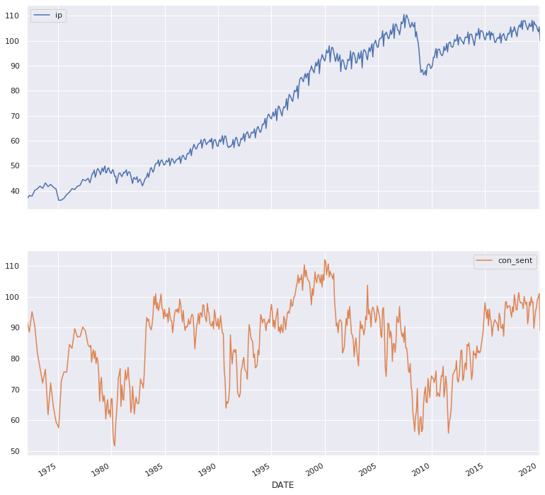

```python
df.plot(subplots=True, figsize=(13,13));
```

# EDA

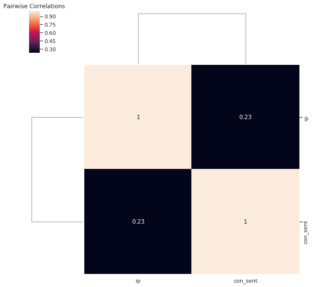

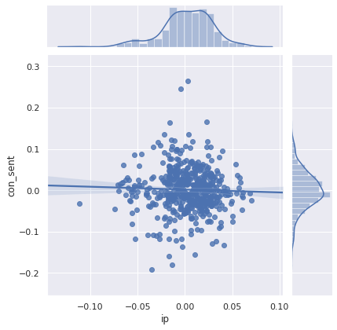

```python
g = sns.clustermap(df.corr(), annot=True)
ax = g.ax_heatmap
bottom, top = ax.get_ylim()
ax.set_ylim(bottom + 0.5, top - 0.5)
plt.title('Pairwise Correlations')
plt.show()

sns.jointplot(x=df.ip.pct_change().dropna(), y=df.con_sent.pct_change().dropna(), kind="reg");
```

The next step in the analysis is to check for causality amongst these series. The **Granger’s Causality test** and the **Cointegration** test can help us with that.

# Testing Causation using Granger’s Causality Test

The Granger causality test is a statistical hypothesis test for determining whether one time series is useful in forecasting another. Ordinarily, regressions reflect "mere" correlations, but Clive Granger argued that causality in economics could be tested for by measuring the ability to predict the future values of a time series using prior values of another time series. Since the question of "true causality" is deeply philosophical, and because of the post hoc fallacy of assuming that one thing preceding another can be used as a proof of causation, econometricians assert that the Granger test finds only "predictive causality". Rather than testing whether `Y` causes `X`, the Granger causality tests whether `Y` forecasts `X`.

A time series `X` is said to Granger-cause `Y` if it can be shown, usually through a series of `t-tests` and `F-tests` on lagged values of `X` (and with lagged values of `Y` also included), that those `X` values provide statistically significant information about future values of `Y`. The original definition of Granger causality does not account for latent confounding effects and does not capture instantaneous and non-linear causal relationships.

In simpler terms, the past values of time series `(X)` do not cause the other series `(Y)`. So, if the p-value obtained from the test is lesser than the significance level of `0.05`, then, you can safely reject the null hypothesis.

The below code implements the Granger’s Causality test for all possible combinations of each time series in a given dataframe and stores the p-values of each combination in matrix form.

```python
maxlag = 12
test = 'ssr_chi2test'

def grangers_causation_matrix(data, variables, test='ssr_chi2test', verbose=False):
    df = pd.DataFrame(np.zeros((len(variables), len(variables))), columns=variables, index=variables)
    for c in df.columns:
        for r in df.index:
            test_result = grangercausalitytests(data[[r, c]], maxlag=maxlag, verbose=False)
            p_values = [round(test_result[i+1][0][test][1],4) for i in range(maxlag)]
            if verbose: print(f'Y = {r}, X = {c}, P Values = {p_values}')
            min_p_value = np.min(p_values)
            df.loc[r, c] = min_p_value
    df.columns = [var + '_x' for var in variables]
    df.index = [var + '_y' for var in variables]
    return df
```

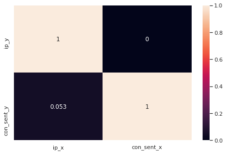

```python
grangers_df = grangers_causation_matrix(df, variables = df.columns)

plt.figure(figsize=(8,5))
sns.heatmap(grangers_df, annot=True)
b, t = plt.ylim()
b += 0.5
t -= 0.5
plt.ylim(b, t)
plt.show()
```

## Find Significant Pairs in a p-value matrix

```python
pairs = grangers_df.unstack()
pairs = pairs.sort_values(kind="quicksort")
mask = pairs < 0.05

print("Significan Pairs")
print(pairs[mask])
```

```
Significan Pairs
con_sent_x  ip_y    0.0
dtype: float64
```

# Cointegration Test

Cointegration test helps to establish the presence of a statistically significant connection between two or more time series. Cointegration is a statistical property of two or more time-series variables which indicates if a linear combination of the variables is stationary.

When two or more time series are cointegrated, it means they have a long run, statistically significant relationship.

This is the basic premise on which Vector Autoregression(VAR) models is based on. So it is common to implement the cointegration test before starting to build VAR models.

Implementation of the cointegration test in python’s statsmodels can see below:

```python
def find_cointegrated_pairs(dataframe, critial_level = 0.05):
    n = dataframe.shape[1]
    pvalue_matrix = np.ones((n, n))
    keys = dataframe.columns
    pairs = []
    for i in range(n):
        for j in range(i+1, n):
            series1 = dataframe[keys[i]]
            series2 = dataframe[keys[j]]
            result = sm.tsa.stattools.coint(series1, series2)
            pvalue = result[1]
            pvalue_matrix[i, j] = pvalue
            if pvalue < critial_level:
                pairs.append((keys[i], keys[j], pvalue))
    return pvalue_matrix, pairs
```

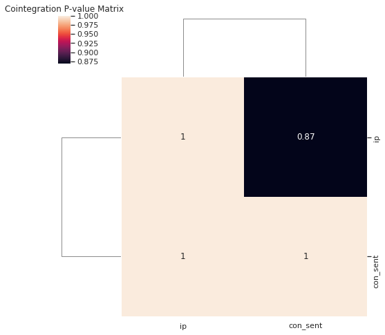

```python
pvalue_matrix, pairs = find_cointegrated_pairs(df)
coint_pvalue_matrix_df = pd.DataFrame(pvalue_matrix)

g = sns.clustermap(coint_pvalue_matrix_df, xticklabels=df.columns,yticklabels=df.columns, annot=True,
                   figsize=(8, 8))
plt.title('Cointegration P-value Matrix')
ax = g.ax_heatmap
bottom, top = ax.get_ylim()
ax.set_ylim(bottom + 0.5, top - 0.5)
plt.show()
```

```python
pairs
```

```
[]
```

Pair is not significant

# Check for Stationarity

Since the VAR model requires the time series you want to forecast to be stationary, it is customary to check all the time series in the system for stationarity.

A stationary time series is one whose mean and variance does not change over time.

So, how to test for stationarity?

There is a suite of tests called unit-root tests. The popular ones are:

- **Augmented Dickey-Fuller Test (ADF Test)**
- **KPSS test**
- **Philip-Perron test**

Let’s implement the **ADF Test** by using our `plot_correlogram()` function which retuns a p-value for the ADF test.

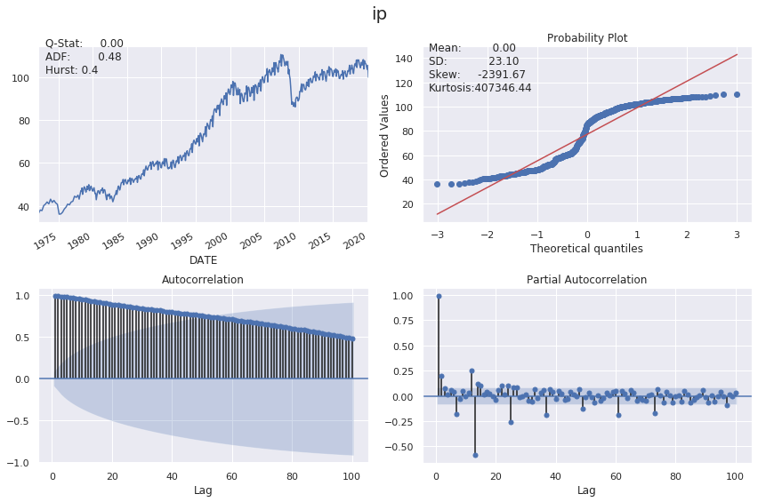

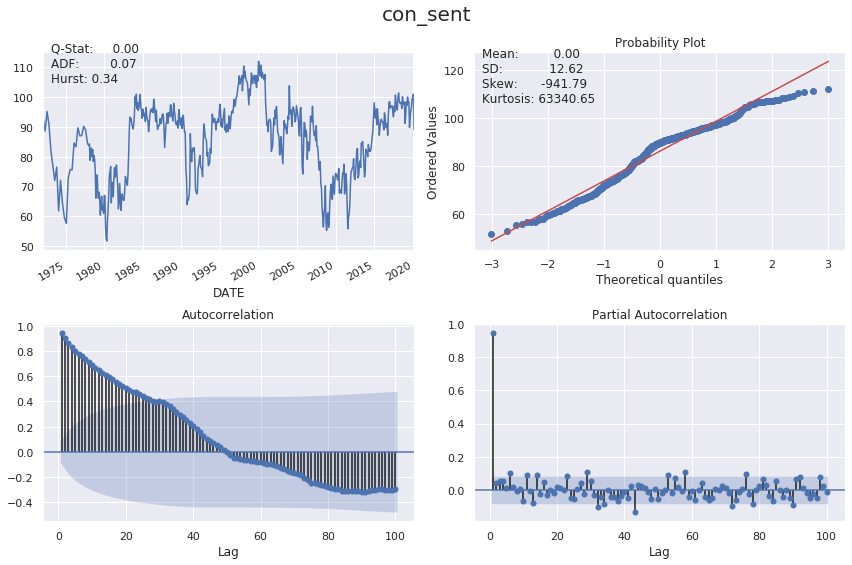

```python
for i in df.columns:
    plot_correlogram(df[i], lags=100, title=f'{i}')
```

## Stationarity Transform

Log-transforming the industrial production and differencing both series using lag `12` yields stationary results:

```python
df_transformed = pd.DataFrame({'ip': np.log(df.ip).diff(12),
                               'con_sent': df.con_sent.diff(12)}).dropna()
```

## Inspect Correlograms

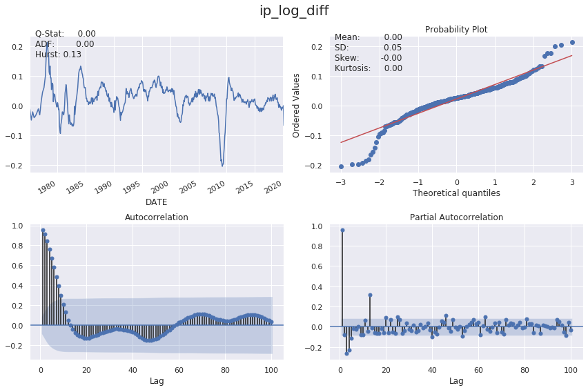

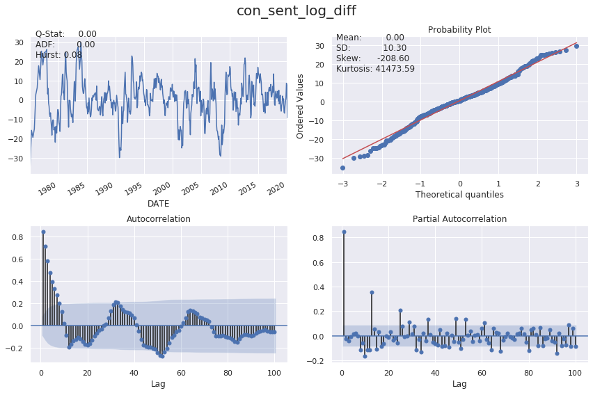

```python
for i in df_transformed.columns:
    plot_correlogram(df_transformed[i], lags=100, title=f'{i}_log_diff')
```

```python
test_unit_root(df_transformed)
```

|  | p-value |
| --- | --- |
| ip | 0.04% |
| con_sent | 0.00% |

All the series are now stationary.

## Split the Series into Training and Testing Data

```python
split = int(len(df) * 0.91)
df_train, df_test = df_transformed.iloc[:split], df_transformed.iloc[split:]
print(df_train.info())
print(df_test.info())
```

```
<class 'pandas.core.frame.DataFrame'>
DatetimeIndex: 483 entries, 1975-02-01 to 2017-03-01
Data columns (total 2 columns):
ip          483 non-null float64
con_sent    483 non-null float64
dtypes: float64(2)
memory usage: 11.3 KB
None
<class 'pandas.core.frame.DataFrame'>
DatetimeIndex: 36 entries, 2017-04-01 to 2020-03-01
Data columns (total 2 columns):
ip          36 non-null float64
con_sent    36 non-null float64
dtypes: float64(2)
memory usage: 864.0 bytes
None
```

### How to Select the Order (P) of VAR model

To select the right order of the VAR model, we iteratively fit increasing orders of VAR model and pick the order that gives a model with least `BIC`.

```python
test_results = {}

for p in range(5):
    for q in range(5):
        if p == 0 and q == 0:
            continue

        print(f'Testing Order: p = {p}, q = {q}')
        convergence_error = stationarity_error = 0

        try:
            model = VARMAX(df_train, order=(p,q), trend='n')
            model_result = model.fit(maxiter=1000, disp=False)

        except LinAlgError:
            convergence_error += 1

        except ValueError:
            stationarity_error += 1

        print('\nAIC:', model_result.aic)
        print('BIC:', model_result.bic)
        print('HQIC:', model_result.hqic)
        print('------------------------')

        test_results[(p, q)] = [model_result.aic,
                                model_result.bic,
                                convergence_error,
                                stationarity_error]
```

```
Testing Order: p = 0, q = 1

AIC: 1371.7385572753833
BIC: 1400.9986738509513
HQIC: 1383.237050802628
------------------------
Testing Order: p = 0, q = 2

AIC: 1135.7477512608878
BIC: 1181.727934451066
HQIC: 1153.8168125179864
------------------------
Testing Order: p = 0, q = 3

AIC: 1275.252227239983
BIC: 1337.9524770447717
HQIC: 1299.8918562269357
------------------------
Testing Order: p = 0, q = 4

AIC: 1029.4102305196916
BIC: 1108.8305469390905
HQIC: 1060.6204272364985
------------------------
Testing Order: p = 1, q = 0

AIC: 161.69557649494536
BIC: 190.95569307051335
HQIC: 173.19407002218995
------------------------
Testing Order: p = 1, q = 1

AIC: 163.52700208187827
BIC: 209.50718527205657
HQIC: 181.59606333897693
------------------------
Testing Order: p = 1, q = 2

AIC: 144.24090067444996
BIC: 206.94115047923856
```

[output cut: 89 more lines]

```
BIC: 264.168539710467
HQIC: 195.6594222383624
------------------------
Testing Order: p = 4, q = 3

AIC: 157.9605559838041
BIC: 287.54107224703387
HQIC: 208.88245589017305
------------------------
Testing Order: p = 4, q = 4

AIC: 156.7242040017988
BIC: 303.02478687963884
HQIC: 214.21667163802175
------------------------
```

```python
test_results = pd.DataFrame(test_results).T
test_results.columns = ['AIC', 'BIC', 'convergence', 'stationarity']
test_results.index.names = ['p', 'q']
test_results.info()
```

```
<class 'pandas.core.frame.DataFrame'>
MultiIndex: 24 entries, (0, 1) to (4, 4)
Data columns (total 4 columns):
AIC             24 non-null float64
BIC             24 non-null float64
convergence     24 non-null float64
stationarity    24 non-null float64
dtypes: float64(4)
memory usage: 1012.0 bytes
```

#### We aim to minimize BIC:

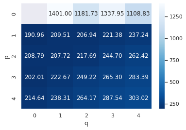

```python
sns.heatmap(test_results.BIC.unstack(), fmt='.2f', annot=True, cmap='Blues_r')
b, t = plt.ylim()
b += 0.5
t -= 0.5
plt.ylim(b, t)
plt.show()
```

```python
test_results.sort_values('BIC').head()
```

| p | q | AIC | BIC | convergence | stationarity |
| --- | --- | --- | --- | --- | --- |
| 1 | 0 | 161.695576 | 190.955693 | 0.0 | 0.0 |
| 3 | 0 | 139.305891 | 202.006140 | 0.0 | 0.0 |
| 1 | 2 | 144.240901 | 206.941150 | 0.0 | 0.0 |
| 2 | 1 | 145.018078 | 207.718328 | 0.0 | 0.0 |
|  | 0 | 162.811494 | 208.791677 | 0.0 | 0.0 |

# Estimating with the best VAR Model

```python
model = VARMAX(df_train, order=(1,0), trend='n').fit(maxiter=1000)
model.summary()
```

Statespace Model Results

| Dep. Variable: | ['ip', 'con_sent'] | No. Observations: | 483 |
| --- | --- | --- | --- |
| Model: | VAR(1) | Log Likelihood | -73.848 |
| Date: | Sun, 26 Apr 2020 | AIC | 161.696 |
| Time: | 19:14:21 | BIC | 190.956 |
| Sample: | 0 | HQIC | 173.194 |
|  | - 483 |  |  |
| Covariance Type: | opg |  |  |

| Ljung-Box (Q): | 131.02, 172.32 | Jarque-Bera (JB): | 145.74, 16.20 |
| --- | --- | --- | --- |
| Prob(Q): | 0.00, 0.00 | Prob(JB): | 0.00, 0.00 |
| Heteroskedasticity (H): | 0.45, 1.11 | Skew: | 0.18, 0.20 |
| Prob(H) (two-sided): | 0.00, 0.52 | Kurtosis: | 5.67, 3.80 |

Results for equation ip

|  | coef | std err | z | P>\|z\| | [0.025 | 0.975] |
| --- | --- | --- | --- | --- | --- | --- |
| L1.ip | 0.9397 | 0.009 | 107.585 | 0.000 | 0.923 | 0.957 |
| L1.con_sent | 0.0006 | 5.24e-05 | 10.948 | 0.000 | 0.000 | 0.001 |

Results for equation con_sent

|  | coef | std err | z | P>\|z\| | [0.025 | 0.975] |
| --- | --- | --- | --- | --- | --- | --- |
| L1.ip | -8.4967 | 4.208 | -2.019 | 0.043 | -16.743 | -0.250 |
| L1.con_sent | 0.8681 | 0.018 | 48.206 | 0.000 | 0.833 | 0.903 |

Error covariance matrix

|  | coef | std err | z | P>\|z\| | [0.025 | 0.975] |
| --- | --- | --- | --- | --- | --- | --- |
| sqrt.var.ip | 0.0128 | 0.000 | 42.008 | 0.000 | 0.012 | 0.013 |
| sqrt.cov.ip.con_sent | 0.0764 | 0.222 | 0.344 | 0.731 | -0.359 | 0.512 |
| sqrt.var.con_sent | 5.2497 | 0.141 | 37.186 | 0.000 | 4.973 | 5.526 |

Warnings:  
[1] Covariance matrix calculated using the outer product of gradients (complex-step).

## Plot Diagnostics

statsmodels provides diagnostic plots to check whether the residuals meet the white noise assumptions, which are not exactly met in this simple case:

Industrial Production

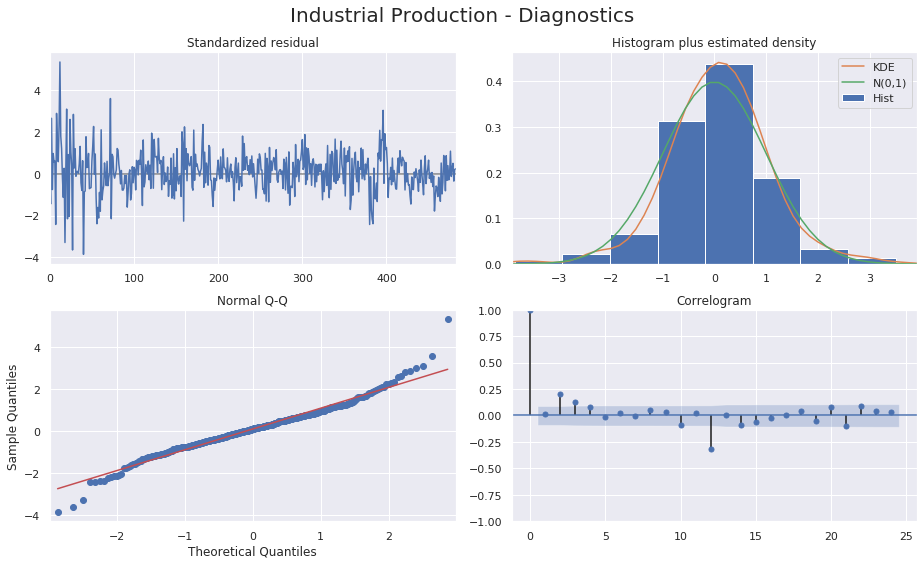

```python
model.plot_diagnostics(variable=0, figsize=(13,8), lags=24)
plt.gcf().suptitle('Industrial Production - Diagnostics', fontsize=20)
plt.tight_layout()
plt.subplots_adjust(top=.9);
```

Consumer Sentiment

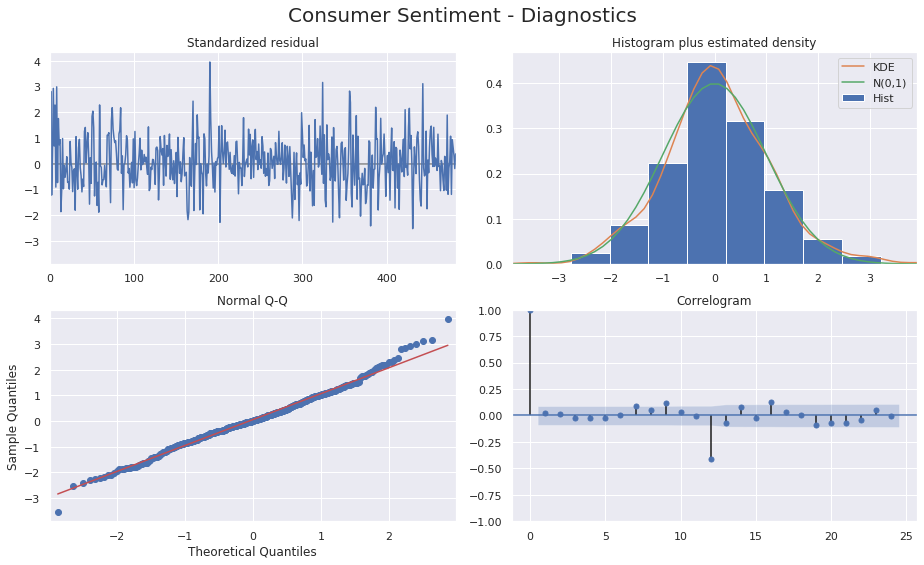

```python
model.plot_diagnostics(variable=1, figsize=(13,8), lags=24)
plt.gcf().suptitle('Consumer Sentiment - Diagnostics', fontsize=20)
plt.tight_layout()
plt.subplots_adjust(top=.9);
```

### Impulse-Response Function

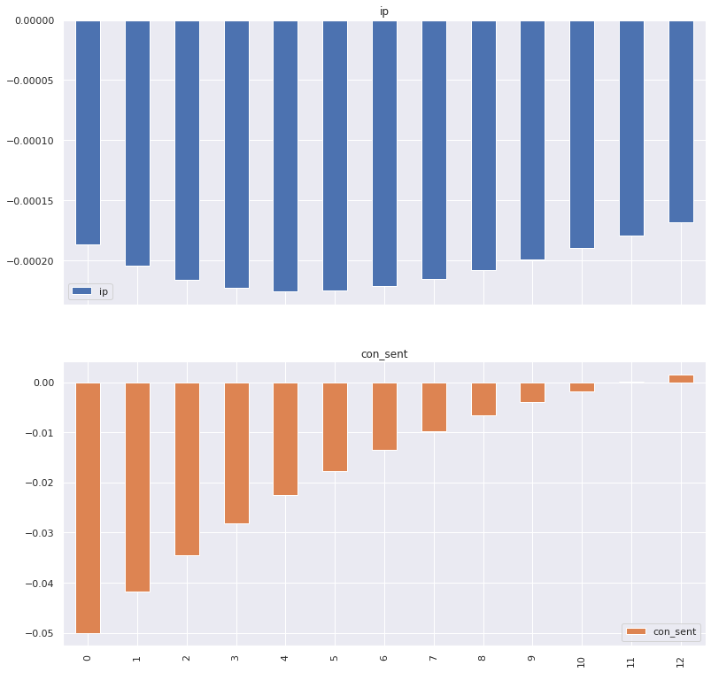

```python
median_change = df_transformed.diff().quantile(.5).tolist()
model.impulse_responses(steps=12, impulse=median_change).plot.bar(subplots=True, figsize=(13,13));
```

# Check for Serial Correlation of Residuals (Errors) using Durbin Watson Statistic

If there is any correlation left in the residuals, then, there is some pattern in the time series that is still left to be explained by the model. In that case, the typical course of action is to either increase the order of the model or induce more predictors into the system. Checking for serial correlation is to ensure that the model is sufficiently able to explain the variances and patterns in the time series.

The value of this statistic can vary between `0` and `4`. The closer it is to the value `2`, then there is no significant serial correlation. The closer to `0`, there is a positive serial correlation, and the closer it is to `4` implies negative serial correlation.

```python
durbin_watson_test(df=df_transformed, resid=model.resid)
```

|  | 0 |
| --- | --- |
| ip | 1.95 |
| con_sent | 1.90 |

## Generate Predictions

Out-of-sample predictions can be generated as follows:

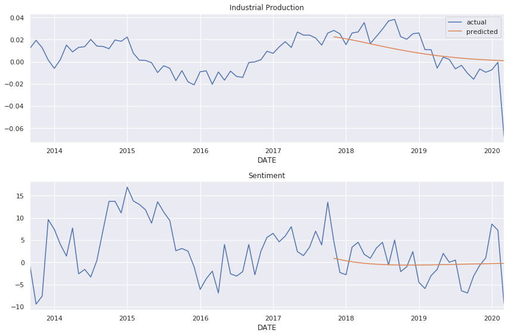

```python
start = 440
preds = model.predict(start=490, end=len(df_transformed)-1)
preds.index = df_transformed.index[490:]

fig, axes = plt.subplots(nrows=2, figsize=(12, 8))

df_transformed.ip.iloc[start:].plot(ax=axes[0], label='actual', title='Industrial Production')
preds.ip.plot(label='predicted', ax=axes[0])
trans = mtransforms.blended_transform_factory(axes[0].transData, axes[0].transAxes)
axes[0].legend()

trans = mtransforms.blended_transform_factory(axes[0].transData, axes[1].transAxes)
df_transformed.con_sent.iloc[start:].plot(ax=axes[1], label='actual', title='Sentiment')
preds.con_sent.plot(label='predicted', ax=axes[1])
fig.tight_layout();
```

## Out-of-sample forecasts

A visualization of actual and predicted values shows how the prediction lags the actual values and does not capture non-linear out-of-sample patterns well:

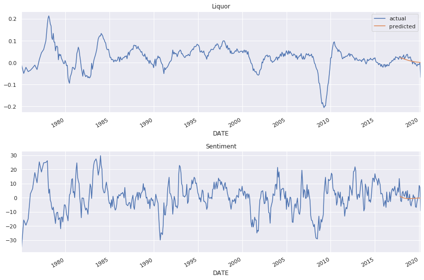

```python
forecast = model.forecast(steps=24)

fig, axes = plt.subplots(nrows=2, figsize=(12, 8))

df_transformed.ip.plot(ax=axes[0], label='actual', title='Liquor')
preds.ip.plot(label='predicted', ax=axes[0])
axes[0].legend()

df_transformed.con_sent.plot(ax=axes[1], label='actual', title='Sentiment')
preds.con_sent.plot(label='predicted', ax=axes[1])
axes[1]
fig.tight_layout();
```

## Model evaluation mean absolute error MAE

```python
mean_absolute_error(forecast, df_transformed.iloc[-24:])
```

```
1.7269717364776123
```